# Analysis of Cross-Sectional Data

## Machine Learning Approaches to Regression

### Kevin Sheppard

# Analysis of Cross-Sectional Data

## Best Subset Regression and Stepwise Regression

- Best Subset Regression
- Forward Stepwise Regression
- Backward Stepwise Regression
- Hybrid Stepwise Regression

# Best Subset Regression

- With $p$ candidate variables, consider all $2^p$ possible models
- For each $k=1,\ldots,p$ find the best model in terms of $SSE$
- From set of $p$ best models, select preferred model using cross-validation
- Example regression is portfolio tracking/replication

$$ VWM_t = \sum_{i=1}^k \beta_i R_{i,t} + \epsilon_t$$

- $R_{i,t}$ are industry portfolio returns
- BSR example uses 15 randomly selected industry portfolios due to computational limits

# Best Subset Regression

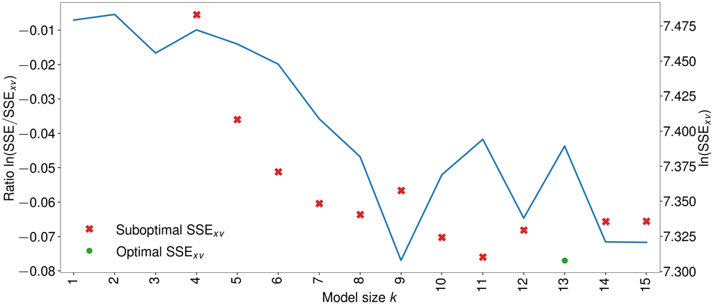

```python
xval_plot(bsr_sse, bsr_sse_xv)
```

# Forward Stepwise Regression

- When $p$ is large Best Subset Regression is computationally impossible
- Forward Stepwise Regression builds a sequence of models using two principles
  1. Start from the previous model with $i$ variables
  2. Considering all excluded variables, **add** the variable to model $i+1$ that produces the **largest reduction in SSE**
- Begins with model $0$ that includes no variables (or possibly a constant)
- Produces a sequence of $p$ (or $p+1$ if a constant) models
- Preferred model is selected from these models using cross-validated SSE

# Forward Stepwise Regression

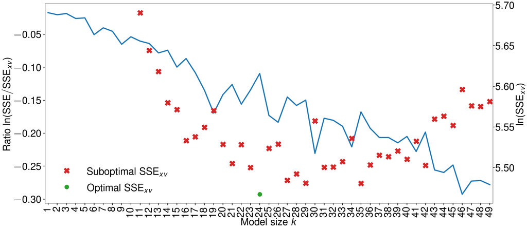

```python
xval_plot(fs_sse, fs_sse_xv)
```

# Backward Stepwise Regression

- Similar to Forward Stepwise only constructed by *removing* variables
- Backward Stepwise Regression builds a sequence of models using two principles
  1. Start from the previous model with $i$ variables
  2. Considering all included variables in model $i$, **remove** the variable that **increases the SSE the least** to construct model $i-1$
- Begins with model $p$ that includes all variables
- Like FSR, produces a sequence of $p$ (or $p+1$ if a constant) models
- Preferred model is selected from these models using cross-validated SSE

# Backward Stepwise Regression

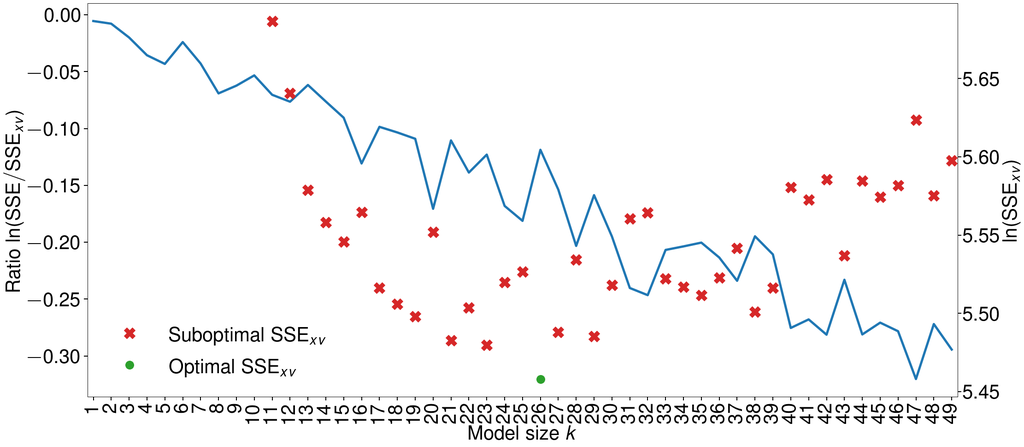

```python
xval_plot(bs_sse, bs_sse_xv)
```

# Comparing Forward and Backward Stepwise Regression

```python
fs_model = fs_models[pd.Series(fs_sse_xv).idxmin()]
bs_model = bs_models[pd.Series(bs_sse_xv).idxmin()]
print(f"Number of common regressors: {len(set(bs_model).intersection(fs_model))}")
print(f"Only in FS: {', '.join(sorted(set(fs_model).difference(bs_model)))}")
print(f"Only in BS: {', '.join(sorted(set(bs_model).difference(fs_model)))}")
```

```
Number of common regressors: 23
Only in FS: Mach
Only in BS: Coal, Fun, Meals
```

# Hybrid Approaches

- Forward and Backward can be combined to produce a larger set of candidate models
- Forward-Backward
  - Use FSR to build select candidate models with $k=1,\ldots,p$ variables
  - Starting with each of these $p$ model, perform Backward Stepwise
- Can be iterated as much as one is willing to wait
- Might better approximate Best Subset Regression
- Final model selected from enlarged set of candidate models by minimizing the cross-validated SSE

```python
print(f"The number of models selected using forward-backward is {len(fb_models)}")
print(f"Not in FS: {', '.join(sorted(set(fb_model).difference(fs_model)))}")
print(f"Not in BS: {', '.join(sorted(set(fb_model).difference(bs_model)))}")
```

```
The number of models selected using forward-backward is 117
Not in FS: Coal, Meals
Not in BS:
```

# Hybrid Approaches

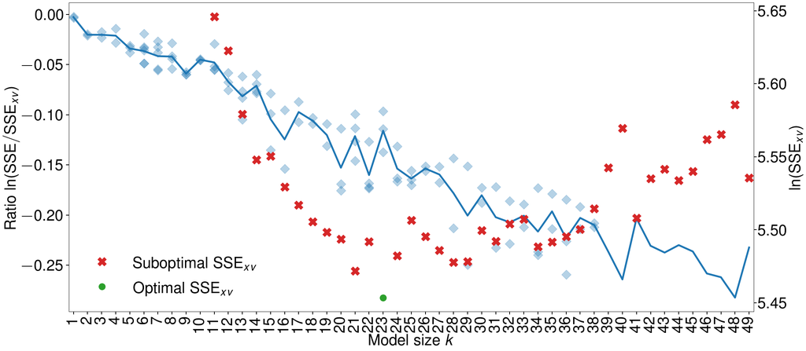

```python
xval_plot(fb_sse, fb_sse_xv, k=fb_k)
```

# Analysis of Cross-Sectional Data

## Shrinkage Estimators

- Ridge Regression
- LASSO: Least Absolute Shrinkage and Selection Operator

**Note**: Important to standardized regressors when using shrinkage estimators

# Ridge Regression

Fit a modified least squares problem

$$ \arg\!\min_{\boldsymbol{\beta}}\,\left(\mathbf{y}-\mathbf{X}\boldsymbol{\beta}\right)^{\prime}\left(\mathbf{y}-\mathbf{X}\boldsymbol{\beta}\right)\text{ subject to }\sum_{j=1}^{k}\beta_{j}^{2}\leq\omega $$

Equivalent formulation

$$ \arg\!\min_{\boldsymbol{\beta}}\,\left(\mathbf{y}-\mathbf{X}\boldsymbol{\beta}\right)^{\prime}\left(\mathbf{y}-\mathbf{X}\boldsymbol{\beta}\right)+\lambda\sum_{j=1}^{k}\beta_{j}^{2}$$

Analytical solution

$$\hat{\boldsymbol{\beta}}^{\textrm{Ridge}}=\left(\mathbf{X}^{\prime}\mathbf{X}+\lambda \mathbf{I}_{k}\right)^{-1}\mathbf{X}^{\prime}\mathbf{y}$$

- $\lambda$ is key shrinkage (ore regularization) parameter
- Optimal $\lambda$ is chosen using cross-validations across a grid of values

# Ridge Regression $\alpha$ Selection

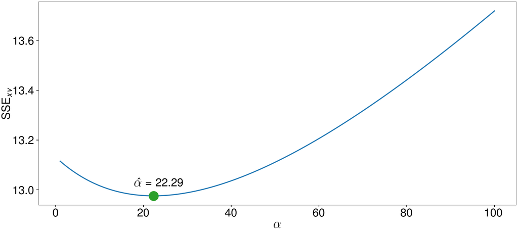

```python
ridge_cv_plot()
```

# Ridge Regression

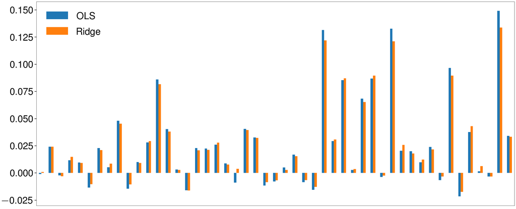

```python
ridge_coef_plot()
```

# LASSO: Least Absolute Shrinkage and Selection Operator

Similar to Ridge but with a different penalty

$$ \arg\!\min_{\boldsymbol{\beta}}\,\left(\mathbf{y}-\mathbf{X}\boldsymbol{\beta}\right)^{\prime}\left(\mathbf{y}-\mathbf{X}\boldsymbol{\beta}\right)\text{ subject to }\sum_{j=1}^{k}\left|\beta_{j}\right|\leq\omega $$

Equivalent formulation

$$ \arg\!\min_{\boldsymbol{\beta}}\,\left(\mathbf{y}-\mathbf{X}\boldsymbol{\beta}\right)^{\prime}\left(\mathbf{y}-\mathbf{X}\boldsymbol{\beta}\right)+\lambda\sum_{j=1}^{k}\left|\beta_{j}\right|$$

- Analytical solution but not easily presentable
- Has special property -- will usually estimate some coefficients to be **exactly** zero
- $\lambda$ is key shrinkage (ore regularization) parameter
- Optimal $\lambda$ is chosen using cross-validations across a grid of values

# LASSO $\alpha$ Selection

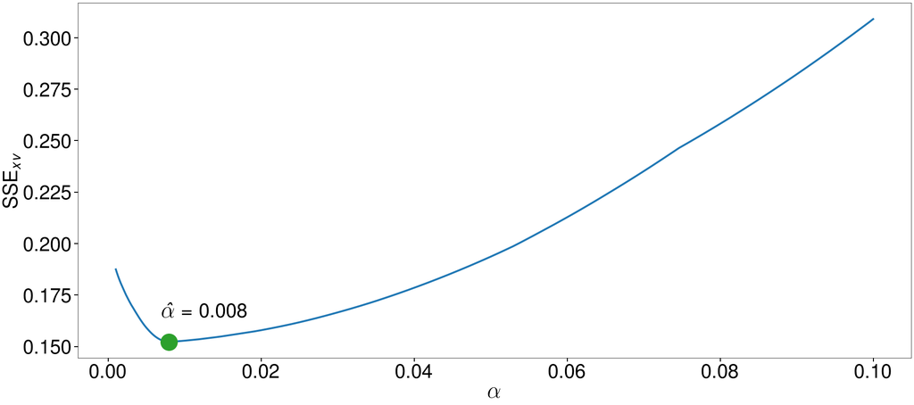

```python
lasso_cv_plot()
```

# LASSO and OLS

```
Number of non-zero coefficients: 30
```

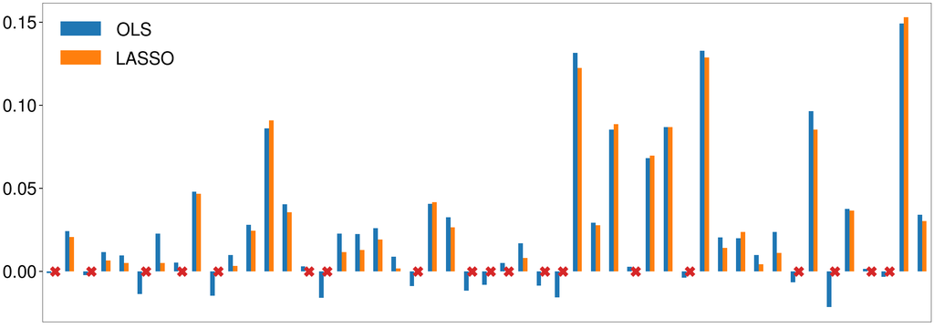

```python
lasso_coef_plot()
```

# The LASSO Coefficient Path

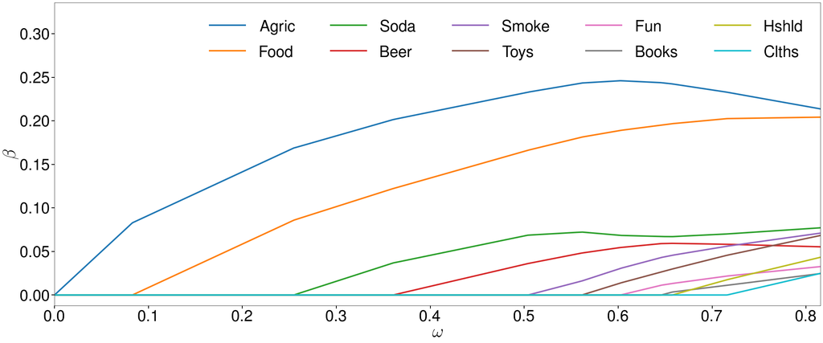

```python
lasso_path_plot()
```

# Alternative constraints in Ridge Regression

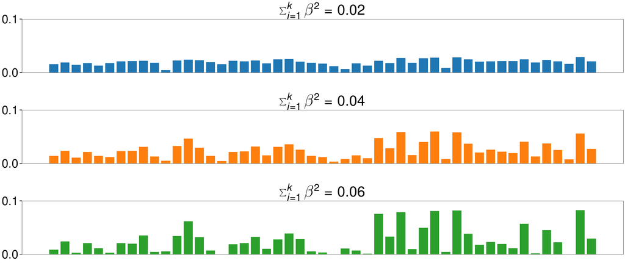

```python
ridge_betas()
```

# Alternative constraints in LASSO

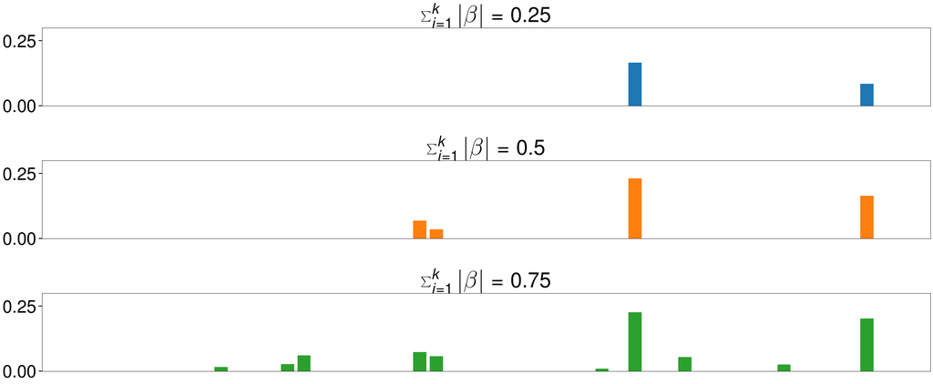

```python
lasso_betas()
```

# Analysis of Cross-Sectional Data

## Tree-based Estimators

- Regression Tree
- Model Representation
- Pruning
- Bagging and Random Forest
- Boosting

# Regression Trees

- Regression Trees build models with **indicator** variables
- Continuous regressors are transformed into Indicator variables

$$X_{i,j}\rightarrow I_{\left[X_{i,j}<X_j^\star\right]}$$

- Model is then build using interaction of indicator variables
- Leads to a tree structure where the tree *splits* on each indicator variable

### Example

- 2-level tree that splits on the market first and then on the return of the size

$$ I_{\left[VWM<0\right]} I_{\left[SMB<1.2\right]} $$

- Parameter estimates are simply averages of $Y_i$ values where indicators are true

$$ \frac{1}{m^\star}\sum_{i=1}^n Y_{i} \left(I_{\left[VWM_i<0\right]} I_{\left[SMB_i<1.2\right]}\right) $$

- $m^\star=\sum_{i=1}^n I_{\left[VWM_i<0\right]} I_{\left[SMB_i<1.2\right]}$ counts the observation in this branch

# Regression Trees

## Two level depiction

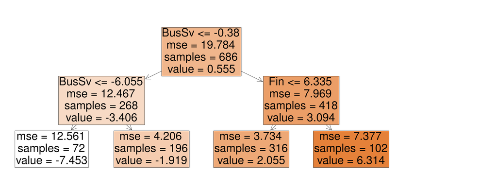

```python
show_tree()
```

# Regression Trees

## Model Representation

- 2-level tree is regression model

$$ \begin{array}{rl} VWM_i = & \beta_1 I_{\left[X_{i,33}\leq -0.38\right]}I_{\left[X_{i,33}\leq -6.055\right]} \\ + & \beta_2 I_{\left[X_{i,33}\leq -0.38\right]}I_{\left[X_{i,33}> -6.055\right]} \\ + & \beta_3 I_{\left[X_{i,33}> -0.38\right]}I_{\left[X_{i,47}\leq 6.335\right]} \\ + & \beta_4 I_{\left[X_{i,33}> -0.38\right]}I_{\left[X_{i,47}> 6.335\right]} \\ + & \epsilon_i \end{array} $$

# Regression Trees

## Key Parameters

Optimize by choosing one of more of:

- Max depth
- Maximum number of nodes
- Minimum decrease in SSE to add a new node
- Minimum group size to allow further splitting

Optimize choice using cross-validation

# Regression Trees

## Max depth

```
Number of leaves: 640
```

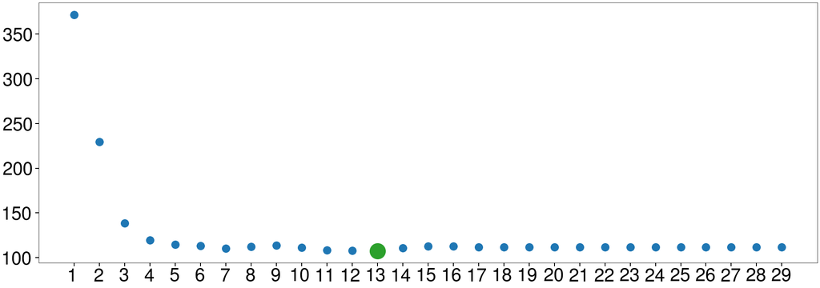

```python
depth_cross_val()
```

# Regression Trees

## Max nodes

```
Maximum Depth: 8
```

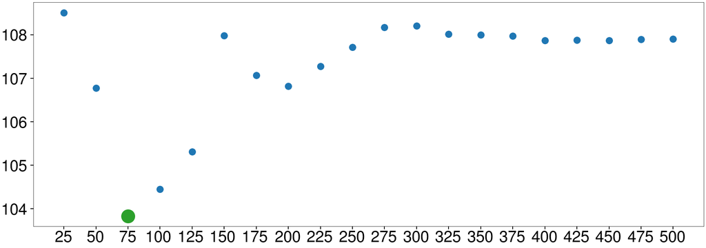

```python
leaves_cross_val()
```

# Pruning

- Pruning can improve trees by removing nodes that make small improvement to the SSE
- Solve a modified objective function $$\sum_{i=1}^{n}\left(Y_{i}-\hat{Y_{i}}\right)^{2}+\alpha\left|T\right|$$
  - $\alpha$ is a tuning parameter
  - $|T|$ is the number of terminal nodes
- Larger values of $\alpha$ reduce tree size
- Select $\alpha$ using cross-validation by pruning a large tree for different values of $\alpha$

# $\alpha$ and tree depth

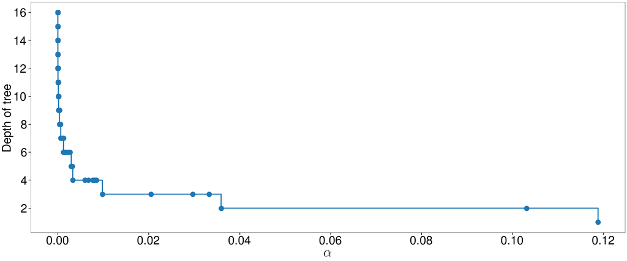

```python
plot_tree_depth()
```

# Selecting $\alpha$ using cross-validation

```
Number of leaves: 96
Maximum Depth: 9
```

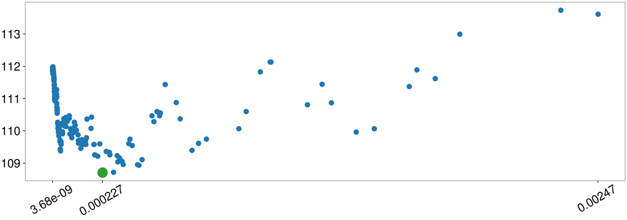

```python
pruning_cross_val()
```

# Random Forests and Bagging

- Bagging (Bootstrap Aggregation) and Random Forests build $B$ trees using $B$ bootstrapped samples
- Prediction is then $$ \hat{f}^{\text{RF}}\left(\mathbf{x}_{i}\right)=B^{-1}\sum_{b=1}^{B}\hat{f}^{\left(b\right)}\left(\mathbf{x}_{i}\right) $$
- Random Forest improves on Bagging since:
  - Each tree is built using only $k\approx\sqrt{p}$ of the variables
  - Produces a set of trees that are weekly correlated because most regressors are excluded from each tree
  - Used when two criteria are met
    - p is large
    - A small number of strong predictors
  - **Note**: Bagging is a special case of a Random Forest when $k=p$
- Similar tuning choices as Regression Tree plus $B$ and $k$

# Random Forest cross-validation

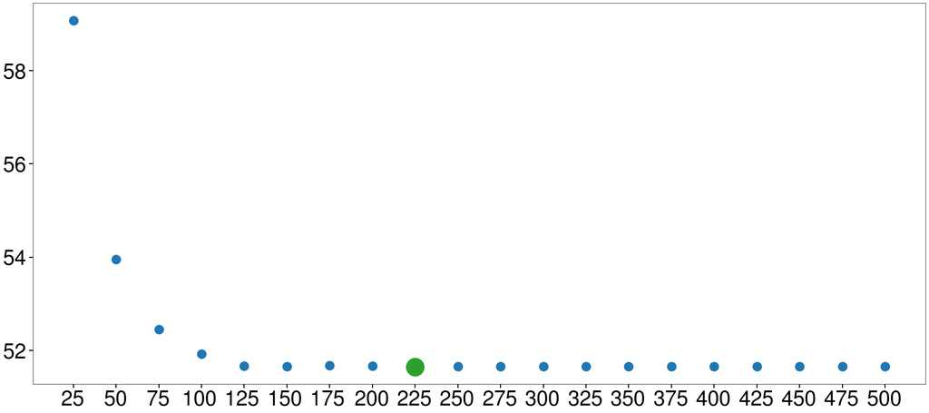

```python
rf_nodes_cross_val("sqrt")
```

# Bagging cross-validation

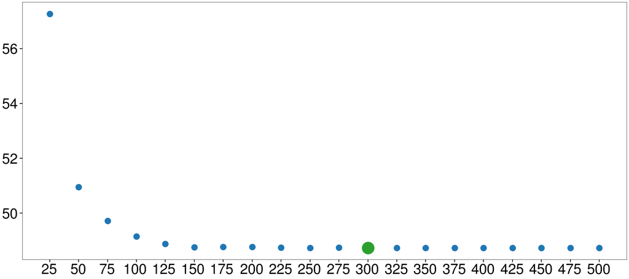

```python
rf_nodes_cross_val("auto")
```

# Boosting

- Boosting fits a sequence of trees each with a small number $d$ terminal nodes
- Each tree is fit to the residuals of the previous tree
  - Child trees focus on fitting observations that were hard to fit by previous trees
  - Nodes are not added for observations that have small prediction errors
  - Building a fresh tree collects all observations in to a single leaf
- Builds models with low-interaction terms
- In a nutshell: build $B$ (large) depth $d$ (small) trees sequentially
- One additional parameter $\lambda$ (small) the slows learning $$\hat{f}\left(\mathbf{x}\right)=\sum_{b=1}^{B}\lambda\hat{f}^{\left(b\right)}\left(\mathbf{x}\right)$$
- $\hat{f}^{\left(b\right)}$ is the prediction of the residuals produced using the previous $b-1$ trees $$\hat{\epsilon}^{(b)}_i=\sum_{i=1}^{b-1}Y_i - \lambda\hat{f}^{\left(i\right)}\left(\mathbf{x}\right)$$
- Three tuning parameters: $B$, $d$ and $\lambda$

# Cross-validating Boosted Trees

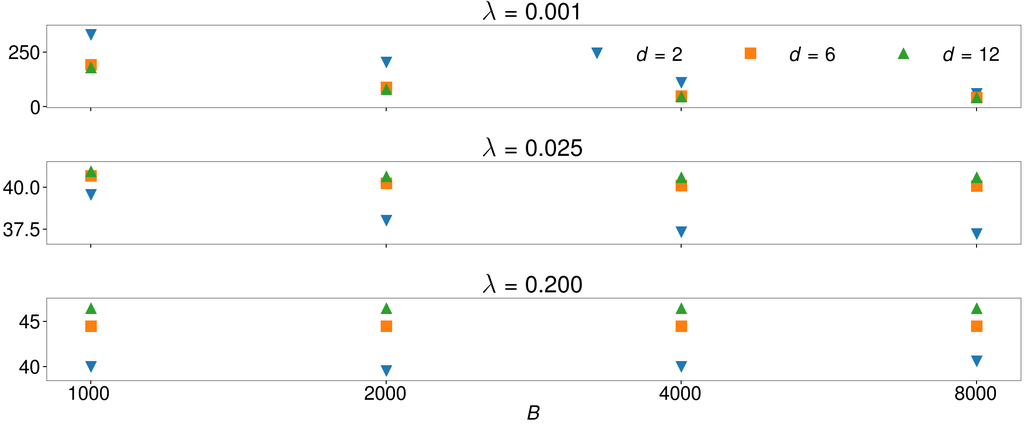

```python
boosting_cv()
```